# Bellabeast_Report

Naratip

2024-01-06

## Introduction

Bellabeat, a high-tech manufacturer of health-focusedproducts for women. Bellabeat is a successful small company, but they have the potential to become a larger player in theglobal smart device market. Urška Sršen, cofounder and Chief Creative Officer of Bellabeat, believes that analyzing smart device fitness data could help unlock new growth opportunities for the company. You have been asked to focus on one of Bellabeat’s products and analyze smart device data to gain insight into how consumers are using their smart devices

**Products** :

- **Bellabeat app**: The Bellabeat app provides users with health data related to their activity, sleep, stress, menstrual cycle, and mindfulness habits. This data can help users better understand their current habits and make healthy decisions. The Bellabeat app connects to their line of smart wellness products.
- **Leaf**: Bellabeat’s classic wellness tracker can be worn as a bracelet, necklace, or clip. The Leaf tracker connects to the Bellabeat app to track activity, sleep, and stress.
- **Time**: This wellness watch combines the timeless look of a classic timepiece with smart technology to track user activity, sleep, and stress. The Time watch connects to the Bellabeat app to provide you with insights into your daily wellness.
- **Spring**: This is a water bottle that tracks daily water intake using smart technology to ensure that you are appropriately hydrated throughout the day. The Spring bottle connects to the Bellabeat app to track your hydration levels.
- **Bellabeat membership**: Bellabeat also offers a subscription-based membership program for users. Membership gives users 24/7 access to fully personalized guidance on nutrition, activity, sleep, health and beauty, and mindfulness based on their lifestyle and goals.

## Business task

1. What are some trends in smart device usage?
2. How could these trends apply to Bellabeat customers?
3. How could these trends help influence Bellabeat marketing strategy?

## Library preparation

```r
install.packages("tidyverse", repos = "http://cran.us.r-project.org")
library("tidyverse")
```

## Preparing Data

Using Data from [FitBit Fitness Tracker Data](https://www.kaggle.com/datasets/arashnic/fitbit) including:

- dailyActivity_merged
- sleepDay_merged

```r
raw_activity <- read_csv("./data/dailyActivity_merged.csv")
raw_sleep <- read_csv("./data/sleepDay_merged.csv")
```

### Activity Data

```r
head(raw_activity)
```

```
## # A tibble: 6 × 15
##           Id ActivityDate TotalSteps TotalDistance TrackerDistance
##        <dbl> <chr>             <dbl>         <dbl>           <dbl>
## 1 1503960366 4/12/2016         13162          8.5             8.5
## 2 1503960366 4/13/2016         10735          6.97            6.97
## 3 1503960366 4/14/2016         10460          6.74            6.74
## 4 1503960366 4/15/2016          9762          6.28            6.28
## 5 1503960366 4/16/2016         12669          8.16            8.16
## 6 1503960366 4/17/2016          9705          6.48            6.48
## # ℹ 10 more variables: LoggedActivitiesDistance <dbl>,
## #   VeryActiveDistance <dbl>, ModeratelyActiveDistance <dbl>,
## #   LightActiveDistance <dbl>, SedentaryActiveDistance <dbl>,
## #   VeryActiveMinutes <dbl>, FairlyActiveMinutes <dbl>,
## #   LightlyActiveMinutes <dbl>, SedentaryMinutes <dbl>, Calories <dbl>
```

### Sleep Data

```r
head(raw_sleep)
```

```
## # A tibble: 6 × 5
##           Id SleepDay        TotalSleepRecords TotalMinutesAsleep TotalTimeInBed
##        <dbl> <chr>                       <dbl>              <dbl>          <dbl>
## 1 1503960366 4/12/2016 0:00                  1                327            346
## 2 1503960366 4/13/2016 12:0…                 2                384            407
## 3 1503960366 4/15/2016 12:0…                 1                412            442
## 4 1503960366 4/16/2016 12:0…                 2                340            367
## 5 1503960366 4/17/2016 12:0…                 1                700            712
## 6 1503960366 4/19/2016 12:0…                 1                304            320
```

## Processing Data

droping irrelevant and duplicate columns from activity data, rename the columns to lowercase, and sort data by date

```r
activity <- select(raw_activity, -c("TrackerDistance", "LoggedActivitiesDistance", "SedentaryActiveDistance")) %>%
  rename_with(tolower) %>%
  rename(total_dis = totaldistance, veryactive_dis = veryactivedistance,moderate_dis = moderatelyactivedistance,
         light_dis = lightactivedistance, veryactive_min = veryactiveminutes, moderate_min = fairlyactiveminutes,
         light_min = lightlyactiveminutes, sedentary_min = sedentaryminutes, date = activitydate) %>%
  arrange(date)
head(activity)
```

```
## # A tibble: 6 × 12
##           id date     totalsteps total_dis veryactive_dis moderate_dis light_dis
##        <dbl> <chr>         <dbl>     <dbl>          <dbl>        <dbl>     <dbl>
## 1 1503960366 4/12/20…      13162     8.5            1.88         0.550     6.06
## 2 1624580081 4/12/20…       8163     5.31           0            0         5.31
## 3 1644430081 4/12/20…      10694     7.77           0.140        2.30      5.33
## 4 1844505072 4/12/20…       6697     4.43           0            0         4.43
## 5 1927972279 4/12/20…        678     0.470          0            0         0.470
## 6 2022484408 4/12/20…      11875     8.34           3.31         0.770     4.26
## # ℹ 5 more variables: veryactive_min <dbl>, moderate_min <dbl>,
## #   light_min <dbl>, sedentary_min <dbl>, calories <dbl>
```

rename the columns of sleep data to lowercase, split date, time, and sort data by date

```r
sleep <- raw_sleep %>% rename_with(tolower) %>%
  rename(date = sleepday, total_record = totalsleeprecords, min_asleep = totalminutesasleep,
         min_bed = totaltimeinbed) %>%
  separate(date, c("date", "time"), sep = " ", extra = "merge") %>%
  arrange(date)
head(sleep)
```

```
## # A tibble: 6 × 6
##           id date      time  total_record min_asleep min_bed
##        <dbl> <chr>     <chr>        <dbl>      <dbl>   <dbl>
## 1 1503960366 4/12/2016 0:00             1        327     346
## 2 1927972279 4/12/2016 0:00             3        750     775
## 3 2026352035 4/12/2016 0:00             1        503     546
## 4 3977333714 4/12/2016 0:00             1        274     469
## 5 4020332650 4/12/2016 0:00             1        501     541
## 6 4445114986 4/12/2016 0:00             2        429     457
```

Finding older and recent date of data

```r
print(min(activity$date))
```

```
## [1] "4/12/2016"
```

```r
print(max(activity$date))
```

```
## [1] "5/9/2016"
```

```r
print(min(sleep$date))
```

```
## [1] "4/12/2016"
```

```r
print(max(sleep$date))
```

```
## [1] "5/9/2016"
```

## Analysis Process

Finding average and standard deviation of step, distance, and average step and time of each activity type, and average calories *distance in km

```r
activity_summary <- activity %>% summarize(step_avg = mean(totalsteps), step_sd = sd(totalsteps),
                                        min_step = min(totalsteps), max_step = max(totalsteps),
                                        dis_avg = mean(total_dis), dis_sd = sd(total_dis),
                                        veryactive_dis_avg = mean(veryactive_dis), veryactive_dis_sd = sd(veryactive_dis),
                                        moderate_dis_avg = mean(moderate_dis), moderate_dis_sd = sd(moderate_dis),
                                        light_dis_avg = mean(light_dis), light_dis_sd = sd(light_dis),
                                        veryactive_time_avg = mean(veryactive_min),
                                        veryactive_time_sd = sd(veryactive_min),
                                        moderate_time_avg = mean(moderate_min), moderate_time_sd = sd(moderate_min),
                                        light_time_avg = mean(light_min), light_time_sd = sd(light_min),
                                        sedentary_time_avg = mean(sedentary_min), sedentary_time_sd = sd(sedentary_min),
                                        calories_avg = mean(calories), calories_sd = sd(calories))
head(activity_summary)
```

```
## # A tibble: 1 × 22
##   step_avg step_sd min_step max_step dis_avg dis_sd veryactive_dis_avg
##      <dbl>   <dbl>    <dbl>    <dbl>   <dbl>  <dbl>              <dbl>
## 1    7638.   5087.        0    36019    5.49   3.92               1.50
## # ℹ 15 more variables: veryactive_dis_sd <dbl>, moderate_dis_avg <dbl>,
## #   moderate_dis_sd <dbl>, light_dis_avg <dbl>, light_dis_sd <dbl>,
## #   veryactive_time_avg <dbl>, veryactive_time_sd <dbl>,
## #   moderate_time_avg <dbl>, moderate_time_sd <dbl>, light_time_avg <dbl>,
## #   light_time_sd <dbl>, sedentary_time_avg <dbl>, sedentary_time_sd <dbl>,
## #   calories_avg <dbl>, calories_sd <dbl>
```

Finding summary group by date There are missing values on 5/11/2016 and 5/12/2016, so drop it

```r
activity_date_summary <- activity %>%
  filter(!((id == 1844505072 & (date == "5/11/2016" | date == "5/12/2016")) |
             (id == 1927972279 & (date == "5/11/2016" | date == "5/12/2016")))) %>%
  select(-"id") %>%
  group_by(date) %>%
  summarise(step_avg = mean(totalsteps), step_sd = sd(totalsteps),
         min_step = min(totalsteps), max_step = max(totalsteps),
         dis_avg = mean(total_dis), dis_sd = sd(total_dis),
         veryactive_dis_avg = mean(veryactive_dis), veryactive_dis_sd = sd(veryactive_dis),
         moderate_dis_avg = mean(moderate_dis), moderate_dis_sd = sd(moderate_dis),
         light_dis_avg = mean(light_dis), light_dis_sd = sd(light_dis),
         veryactive_time_avg = mean(veryactive_min),
         veryactive_time_sd = sd(veryactive_min),
         moderate_time_avg = mean(moderate_min), moderate_time_sd = sd(moderate_min),
         light_time_avg = mean(light_min), light_time_sd = sd(light_min),
         sedentary_time_avg = mean(sedentary_min), sedentary_time_sd = sd(sedentary_min),
         calories_avg = mean(calories), calories_sd = sd(calories)) %>%
  arrange(date)
head(activity_date_summary)
```

```
## # A tibble: 6 × 23
##   date      step_avg step_sd min_step max_step dis_avg dis_sd veryactive_dis_avg
##   <chr>        <dbl>   <dbl>    <dbl>    <dbl>   <dbl>  <dbl>              <dbl>
## 1 4/12/2016    8237.   4874.        0    23186    5.98   3.96               1.83
## 2 4/13/2016    7199.   4085.        0    16433    5.10   3.05               1.33
## 3 4/14/2016    7744.   5248.        0    21129    5.60   4.22               1.51
## 4 4/15/2016    7534.   4728.      980    20669    5.29   3.51               1.06
## 5 4/16/2016    8679.   6433.        0    29326    6.29   5.11               1.99
## 6 4/17/2016    6409.   5121.        0    18827    4.54   3.68               1.15
## # ℹ 15 more variables: veryactive_dis_sd <dbl>, moderate_dis_avg <dbl>,
## #   moderate_dis_sd <dbl>, light_dis_avg <dbl>, light_dis_sd <dbl>,
## #   veryactive_time_avg <dbl>, veryactive_time_sd <dbl>,
## #   moderate_time_avg <dbl>, moderate_time_sd <dbl>, light_time_avg <dbl>,
## #   light_time_sd <dbl>, sedentary_time_avg <dbl>, sedentary_time_sd <dbl>,
## #   calories_avg <dbl>, calories_sd <dbl>
```

Finding summary group by day of week

```r
activity_day_summary <- activity %>% mutate(day = weekdays(as.Date(date, format = "%m/%d/%y"))) %>%
  filter(!((id == 1844505072 & (date == "5/11/2016" | date == "5/12/2016")) |
             (id == 1927972279 & (date == "5/11/2016" | date == "5/12/2016")))) %>%
  select(-c("id","date")) %>%
  group_by(day) %>%
  summarise(step_avg = mean(totalsteps), step_sd = sd(totalsteps),
         min_step = min(totalsteps), max_step = max(totalsteps),
         dis_avg = mean(total_dis), dis_sd = sd(total_dis),
         veryactive_dis_avg = mean(veryactive_dis), veryactive_dis_sd = sd(veryactive_dis),
         moderate_dis_avg = mean(moderate_dis), moderate_dis_sd = sd(moderate_dis),
         light_dis_avg = mean(light_dis), light_dis_sd = sd(light_dis),
         veryactive_time_avg = mean(veryactive_min),
         veryactive_time_sd = sd(veryactive_min),
         moderate_time_avg = mean(moderate_min), moderate_time_sd = sd(moderate_min),
         light_time_avg = mean(light_min), light_time_sd = sd(light_min),
         sedentary_time_avg = mean(sedentary_min), sedentary_time_sd = sd(sedentary_min),
         calories_avg = mean(calories), calories_sd = sd(calories)) %>%
  arrange(ordered(day, levels = c("Sunday", "Monday", "Tuesday", "Wednesday", "Thursday", "Friday","Saturday")))
head(activity_day_summary)
```

```
## # A tibble: 6 × 23
##   day    step_avg step_sd min_step max_step dis_avg dis_sd veryactive_dis_avg
##   <chr>     <dbl>   <dbl>    <dbl>    <dbl>   <dbl>  <dbl>              <dbl>
## 1 จันทร์      7662.   4761.        0    23629    5.56   3.80               1.66
## 2 พฤหัสบดี    8153.   5944.        0    29326    5.85   4.68               1.51
## 3 พุธ        7448.   4648.        0    21727    5.31   3.57               1.31
## 4 ศุกร์       6933.   5644.        0    36019    5.03   4.38               1.49
## 5 อังคาร     7508.   4965.        0    21129    5.39   3.79               1.41
## 6 อาทิตย์     8125.   4834.        0    23186    5.83   3.67               1.61
## # ℹ 15 more variables: veryactive_dis_sd <dbl>, moderate_dis_avg <dbl>,
## #   moderate_dis_sd <dbl>, light_dis_avg <dbl>, light_dis_sd <dbl>,
## #   veryactive_time_avg <dbl>, veryactive_time_sd <dbl>,
## #   moderate_time_avg <dbl>, moderate_time_sd <dbl>, light_time_avg <dbl>,
## #   light_time_sd <dbl>, sedentary_time_avg <dbl>, sedentary_time_sd <dbl>,
## #   calories_avg <dbl>, calories_sd <dbl>
```

### Step trend

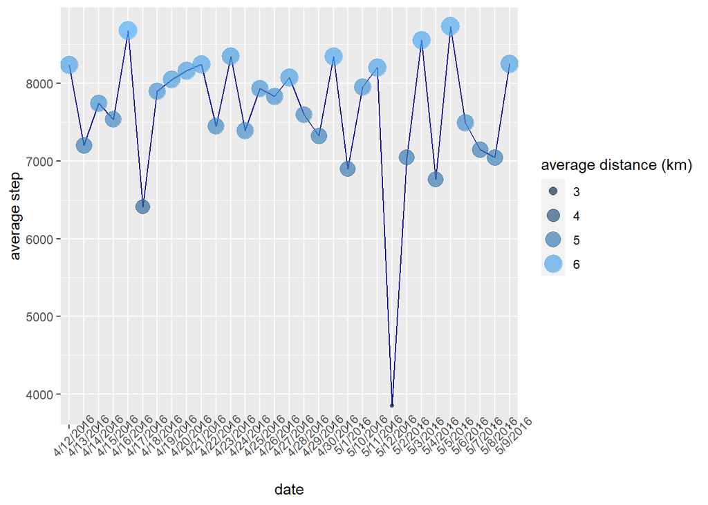

```r
ggplot(data = activity_date_summary, aes(x = fct_inorder(date), y = step_avg, group = 1)) +
  geom_line(color = "darkblue") +
  geom_point(aes(size = dis_avg, color = dis_avg),alpha = 0.7) +
  theme(axis.text.x = element_text(angle = 45)) +
  ylab("average step") +
  xlab("date") +
  guides(color = guide_legend(title = "average distance (km)"), size = guide_legend(title = "average distance (km)"))
```

### Calories plot

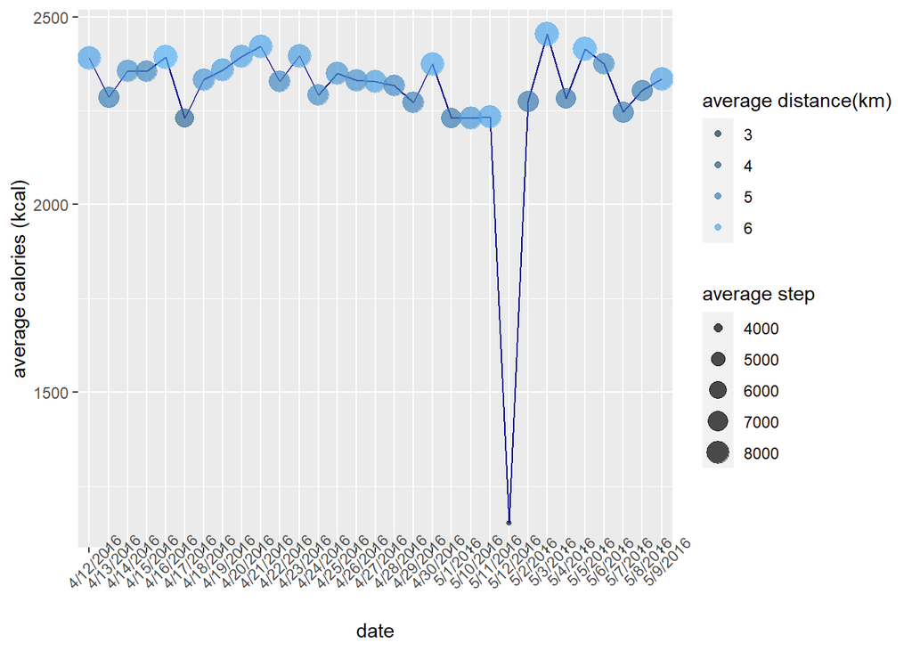

```r
ggplot(data = activity_date_summary, aes(x = fct_inorder(date), y = calories_avg, group = 1)) +
  geom_line(color = "darkblue") +
  geom_point(aes(size = step_avg, color = dis_avg),alpha = 0.7) +
  theme(axis.text.x = element_text(angle = 45)) +
  ylab("average calories (kcal)") +
  xlab("date") +
  guides(color = guide_legend(title = "average distance(km)"), size = guide_legend(title = "average step"))
```

### Distance plot of each active type

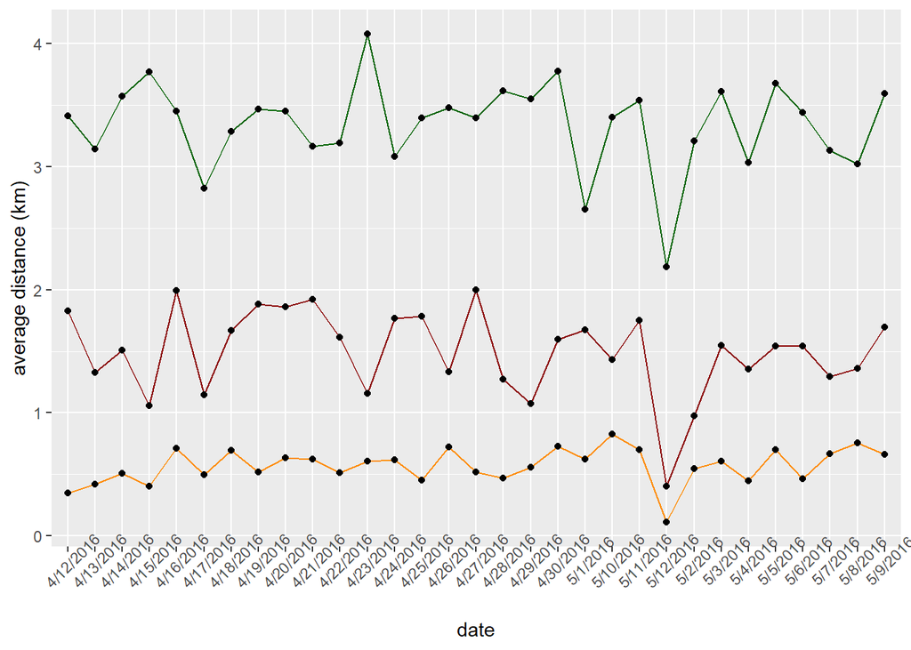

```r
ggplot(data = activity_date_summary, aes(x = fct_inorder(date), y = dis_avg, group = 1)) +
  geom_line(mapping = aes(y = veryactive_dis_avg), color = "darkred") +
  geom_point(mapping = aes(y = veryactive_dis_avg)) +
  geom_line(mapping = aes(y = moderate_dis_avg), color = "darkorange") +
  geom_point(mapping = aes(y = moderate_dis_avg)) +
  geom_line(mapping = aes(y = light_dis_avg), color = "darkgreen") +
  geom_point(mapping = aes(y = light_dis_avg)) +
  theme(axis.text.x = element_text(angle = 45)) +
  ylab("average distance (km)") +
  xlab("date")
```

### Time plot of each active type

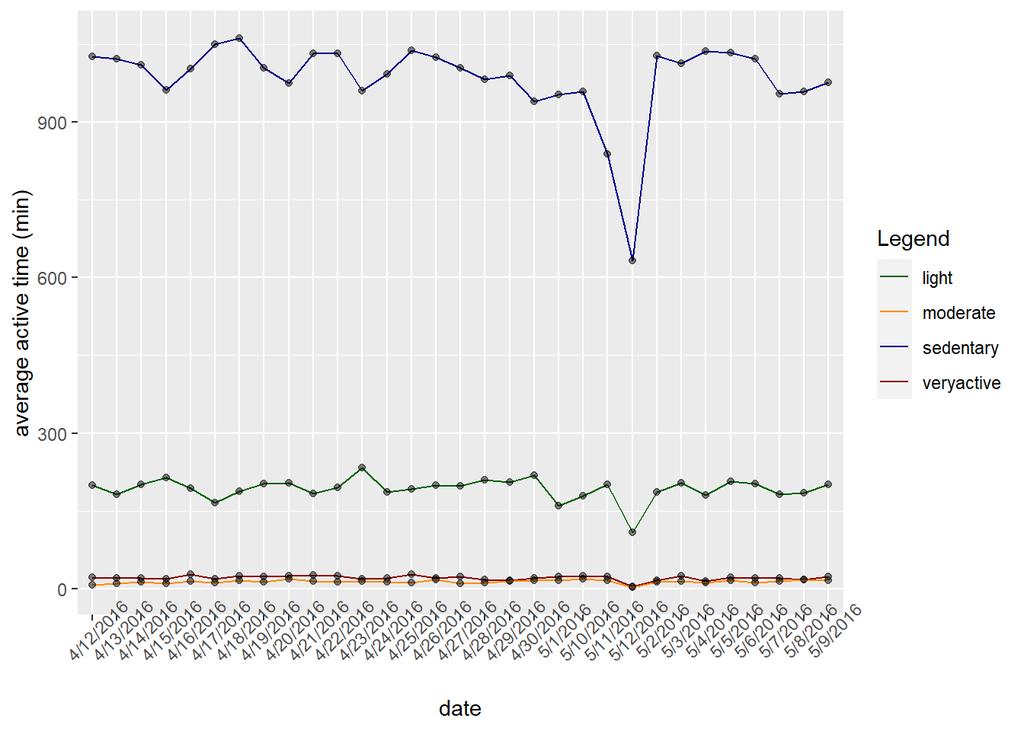

```r
colors <- c("veryactive" = "darkred", "moderate" = "darkorange", "light" = "darkgreen", "sedentary" = "darkblue")
ggplot(data = activity_date_summary, aes(x = fct_inorder(date), group = 1)) +
  scale_color_manual(values = colors) +
  geom_line(mapping = aes(y = veryactive_time_avg, color = "veryactive")) +
  geom_point(mapping = aes(y = veryactive_time_avg), alpha = 0.5) +
  geom_line(mapping = aes(y = moderate_time_avg, color = "moderate")) +
  geom_point(mapping = aes(y = moderate_time_avg), alpha = 0.5) +
  geom_line(mapping = aes(y = light_time_avg, color = "light")) +
  geom_point(mapping = aes(y = light_time_avg), alpha = 0.5) +
  geom_line(mapping = aes(y = sedentary_time_avg, color = "sedentary")) +
  geom_point(mapping = aes(y = sedentary_time_avg), alpha = 0.5) +
  theme(axis.text.x = element_text(angle = 45)) +
  labs(x = "date", y = "average active time (min)", color = "Legend")
```

### Scatter plot calories vs step

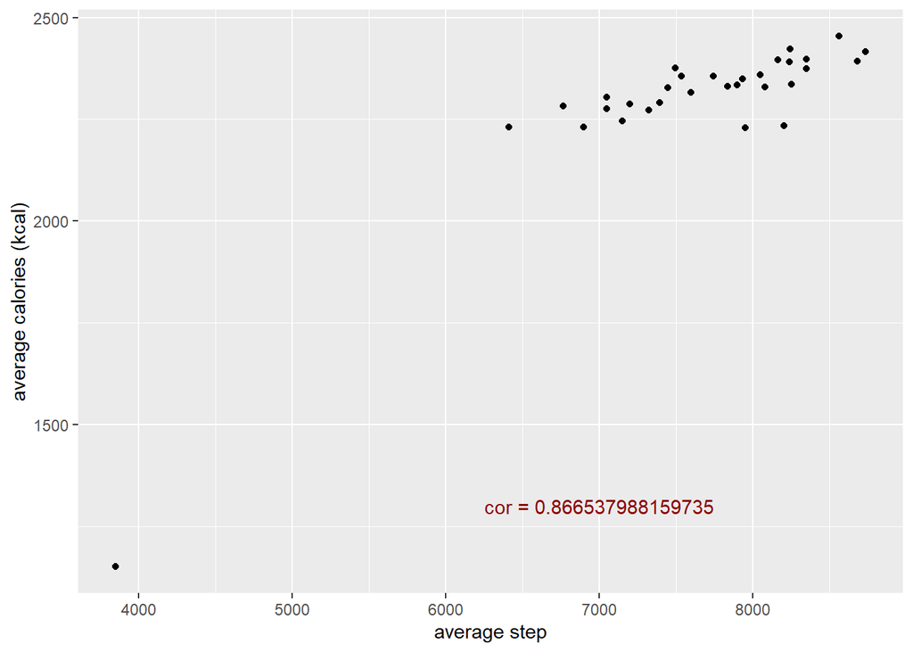

```r
cor_cal_step <- cor(activity_date_summary$calories_avg,activity_date_summary$step_avg)
ggplot(data = activity_date_summary) +
  geom_point(mapping = aes(x = step_avg, y = calories_avg)) +
  annotate("text", x = 7000, y = 1300, label = paste("cor =", cor_cal_step), color = "darkred") +
  labs(x = "average step", y = "average calories (kcal)")
```

### Scatter plot calories vs distance

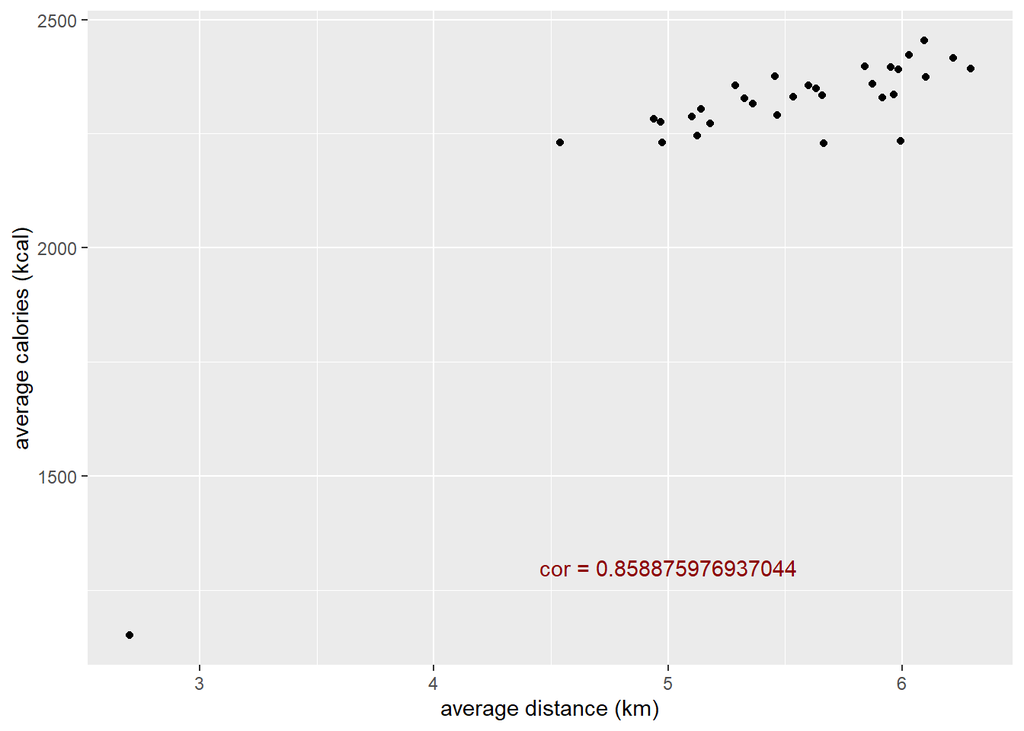

```r
cor_cal_dis <- cor(activity_date_summary$calories_avg,activity_date_summary$dis_avg)
ggplot(data = activity_date_summary) +
  geom_point(mapping = aes(x = dis_avg, y = calories_avg)) +
  annotate("text", x = 5, y = 1300, label = paste("cor =", cor_cal_dis), color = "darkred") +
  labs(x = "average distance (km)", y = "average calories (kcal)")
```

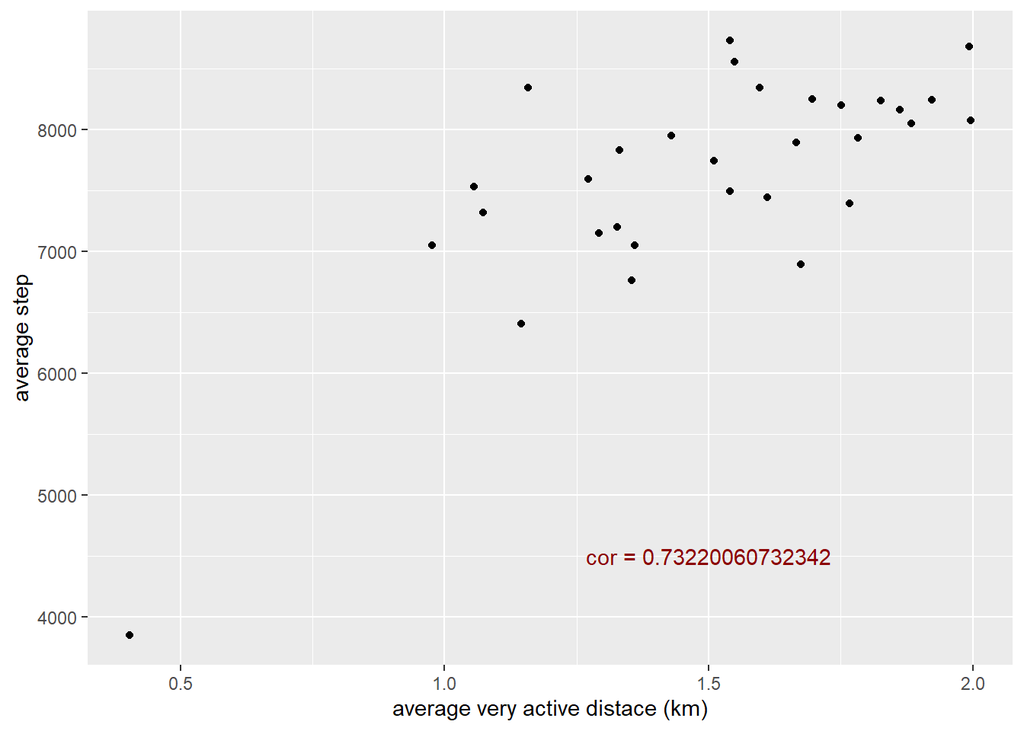

```r
cor_step_active <- cor(activity_date_summary$step_avg,activity_date_summary$veryactive_dis_avg)
ggplot(data = activity_date_summary) +
  geom_point(mapping = aes(x = veryactive_dis_avg, y = step_avg)) +
  annotate("text", x = 1.5, y = 4500, label = paste("cor =", cor_step_active), color = "darkred") +
  labs(x = "average very active distace (km)", y = "average step")
```

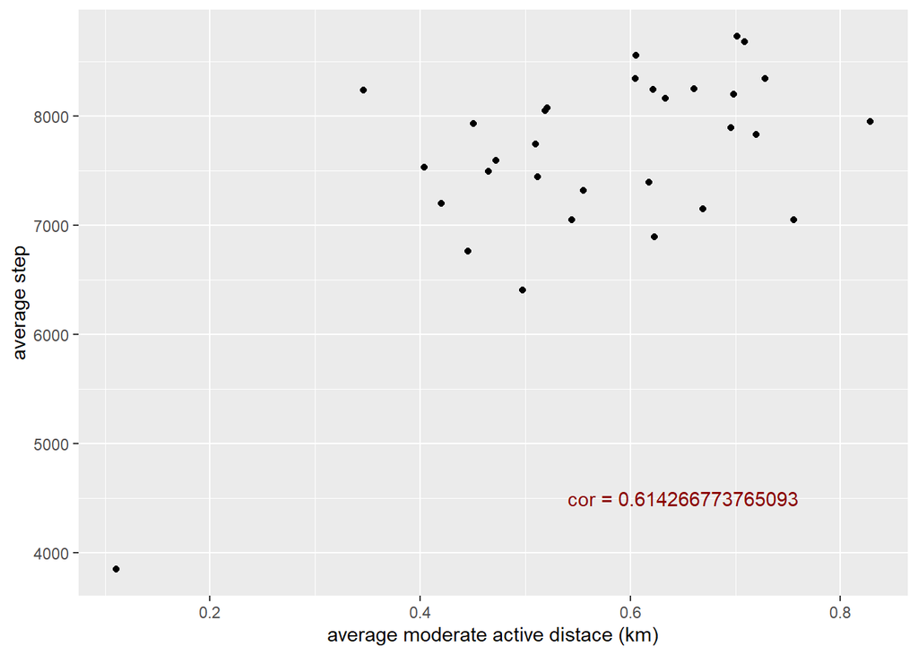

```r
cor_step_moderate <- cor(activity_date_summary$step_avg,activity_date_summary$moderate_dis_avg)
ggplot(data = activity_date_summary) +
  geom_point(mapping = aes(x = moderate_dis_avg, y = step_avg)) +
  annotate("text", x = 0.65, y = 4500, label = paste("cor =", cor_step_moderate), color = "darkred") +
  labs(x = "average moderate active distace (km)", y = "average step")
```

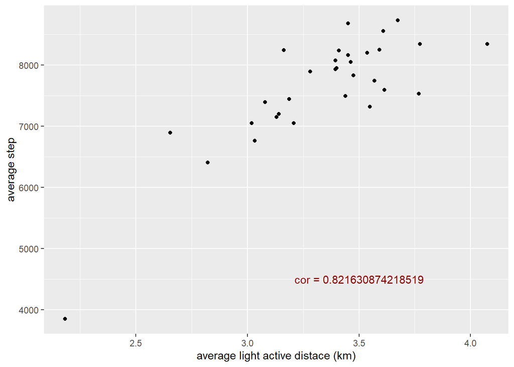

```r
cor_step_light <- cor(activity_date_summary$step_avg,activity_date_summary$light_dis_avg)
ggplot(data = activity_date_summary) +
  geom_point(mapping = aes(x = light_dis_avg, y = step_avg)) +
  annotate("text", x = 3.5, y = 4500, label = paste("cor =", cor_step_light), color = "darkred") +
  labs(x = "average light active distace (km)", y = "average step")
```

### Scatter Plot calories vs each active type distance

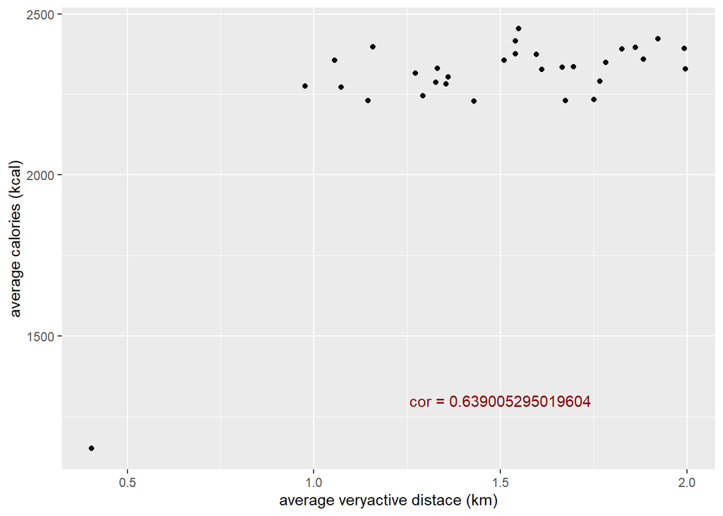

```r
cor_cal_active <- cor(activity_date_summary$calories_avg,activity_date_summary$veryactive_dis_avg)
ggplot(data = activity_date_summary) +
  geom_point(mapping = aes(x = veryactive_dis_avg, y = calories_avg)) +
  annotate("text", x = 1.5, y = 1300, label = paste("cor =", cor_cal_active), color = "darkred") +
  labs(x = "average veryactive distace (km)", y = "average calories (kcal)")
```

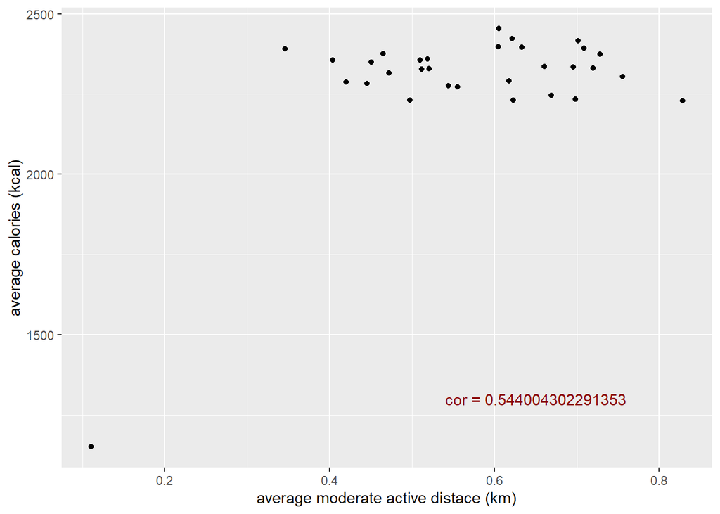

```r
cor_cal_moderate <- cor(activity_date_summary$calories_avg,activity_date_summary$moderate_dis_avg)
ggplot(data = activity_date_summary) +
  geom_point(mapping = aes(x = moderate_dis_avg, y = calories_avg)) +
  annotate("text", x = 0.65, y = 1300, label = paste("cor =", cor_cal_moderate), color = "darkred") +
  labs(x = "average moderate active distace (km)", y = "average calories (kcal)")
```

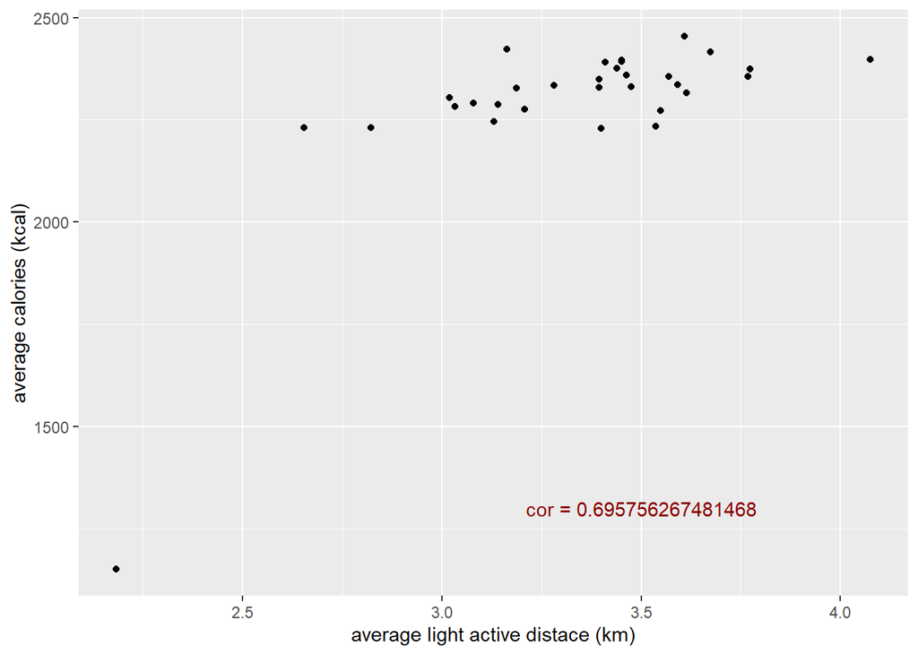

```r
cor_cal_light <- cor(activity_date_summary$calories_avg,activity_date_summary$light_dis_avg)
ggplot(data = activity_date_summary) +
  geom_point(mapping = aes(x = light_dis_avg, y = calories_avg)) +
  annotate("text", x = 3.5, y = 1300, label = paste("cor =", cor_cal_light), color = "darkred") +
  labs(x = "average light active distace (km)", y = "average calories (kcal)")
```

### Scatter plot calories vs each active type time

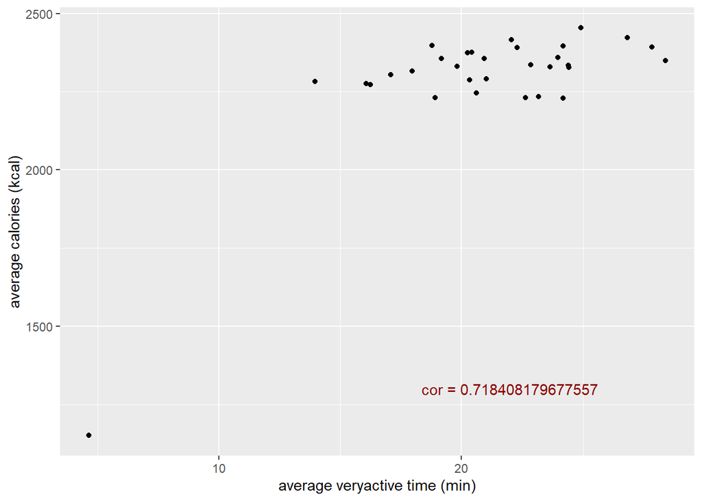

```r
cor_cal_active_t <- cor(activity_date_summary$calories_avg,activity_date_summary$veryactive_time_avg)
ggplot(data = activity_date_summary) +
  geom_point(mapping = aes(x = veryactive_time_avg, y = calories_avg)) +
  annotate("text", x = 22, y = 1300, label = paste("cor =", cor_cal_active_t), color = "darkred") +
  labs(x = "average veryactive time (min)", y = "average calories (kcal)")
```

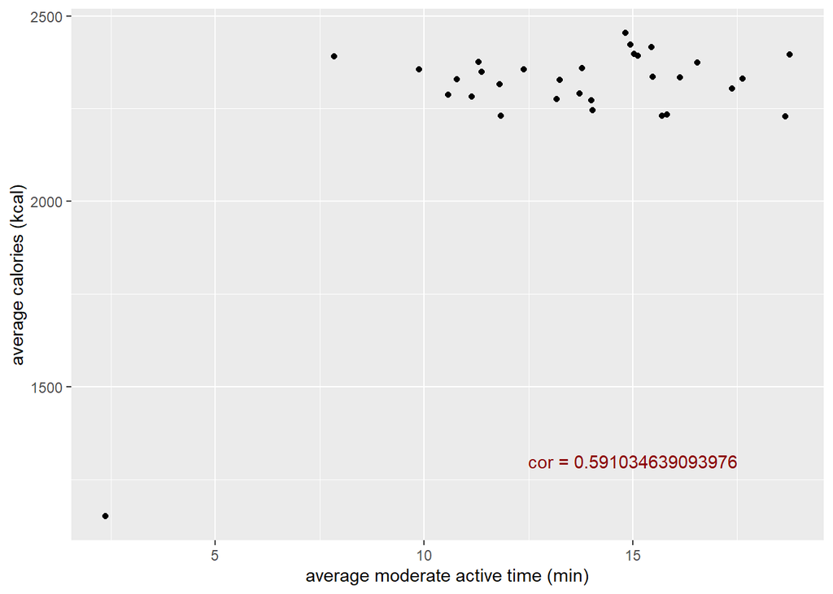

```r
cor_cal_moderate_t <- cor(activity_date_summary$calories_avg,activity_date_summary$moderate_time_avg)
ggplot(data = activity_date_summary) +
  geom_point(mapping = aes(x = moderate_time_avg, y = calories_avg)) +
  annotate("text", x = 15, y = 1300, label = paste("cor =", cor_cal_moderate_t), color = "darkred") +
  labs(x = "average moderate active time (min)", y = "average calories (kcal)")
```

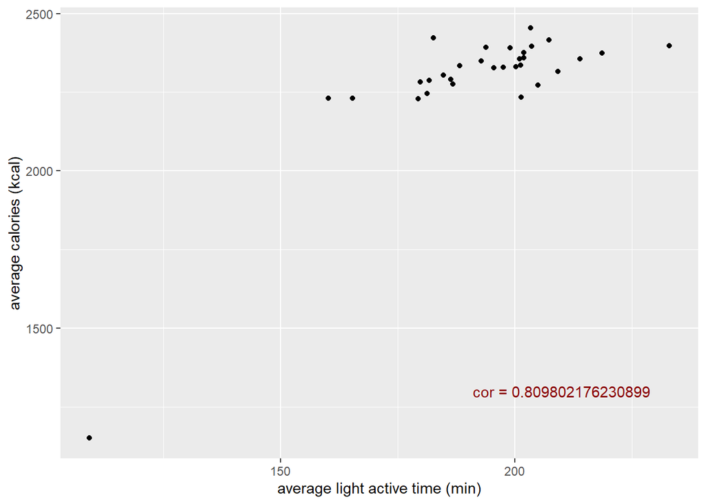

```r
cor_cal_light_t <- cor(activity_date_summary$calories_avg,activity_date_summary$light_time_avg)
ggplot(data = activity_date_summary) +
  geom_point(mapping = aes(x = light_time_avg, y = calories_avg)) +
  annotate("text", x = 210, y = 1300, label = paste("cor =", cor_cal_light_t), color = "darkred") +
  labs(x = "average light active time (min)", y = "average calories (kcal)")
```

### Step Plot

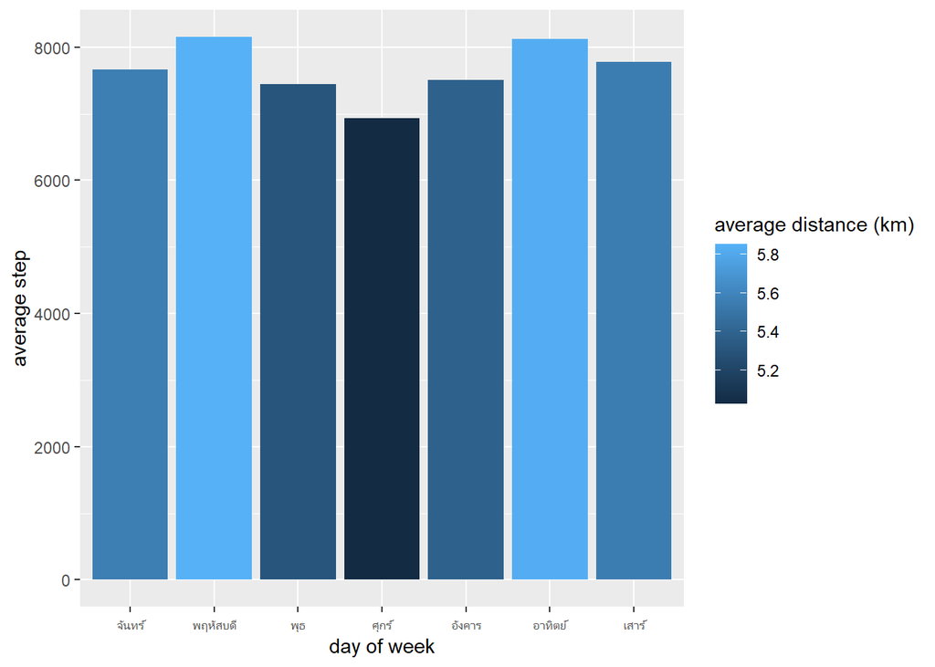

```r
ggplot(data = activity_day_summary) +
  geom_col(mapping = aes(x = fct_inorder(day), y = step_avg, fill = dis_avg)) +
  labs(x = "day of week", y = "average step", fill = "average distance (km)")
```

### Distance plot of each active type

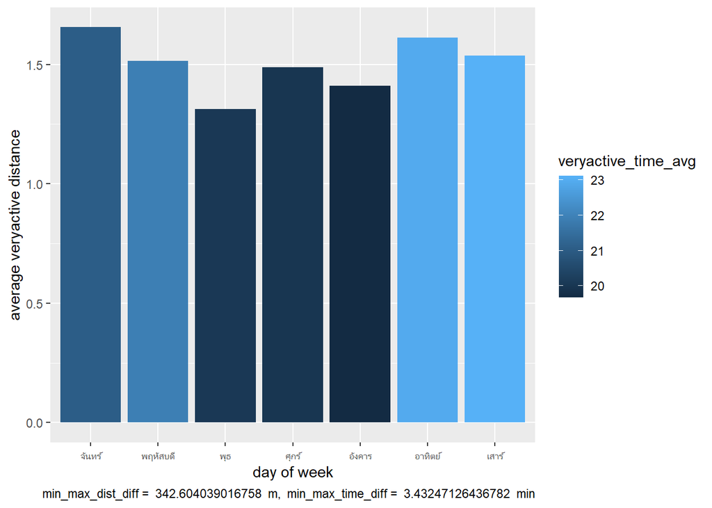

```r
active_dis_diff <- max(activity_day_summary$veryactive_dis_avg) - min(activity_day_summary$veryactive_dis_avg)
active_time_diff <- max(activity_day_summary$veryactive_time_avg) - min(activity_day_summary$veryactive_time_avg)
ggplot(data = activity_day_summary) +
  geom_col(mapping = aes(x = fct_inorder(day), y = veryactive_dis_avg, fill = veryactive_time_avg)) +
  labs(caption = paste("min_max_dist_diff = ",active_dis_diff*1000," m, ","min_max_time_diff = ",
                       active_time_diff, " min"), x = "day of week", y = "average veryactive distance",
       color = "average active time")
```

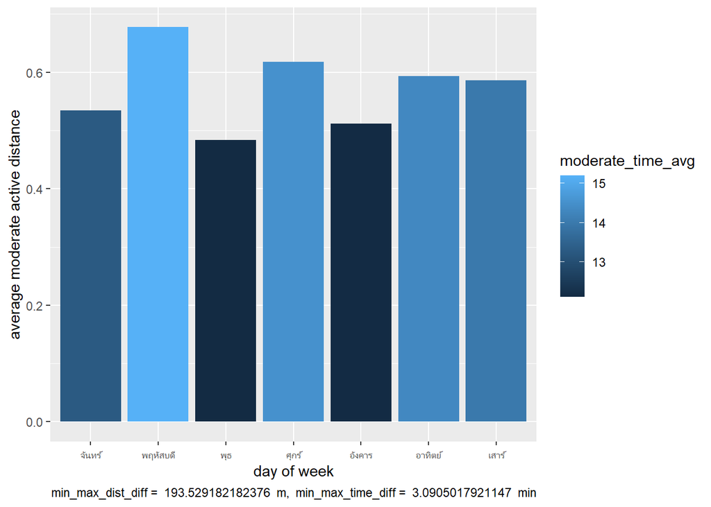

```r
moderate_dis_diff <- max(activity_day_summary$moderate_dis_avg) - min(activity_day_summary$moderate_dis_avg)
moderate_time_diff <- max(activity_day_summary$moderate_time_avg) - min(activity_day_summary$moderate_time_avg)
ggplot(data = activity_day_summary) +
  geom_col(mapping = aes(x = fct_inorder(day), y = moderate_dis_avg, fill = moderate_time_avg)) +
  labs(caption = paste("min_max_dist_diff = ",moderate_dis_diff*1000," m, ","min_max_time_diff = ",
                       moderate_time_diff, " min"), x = "day of week", y = "average moderate active distance",
       color = "average active time")
```

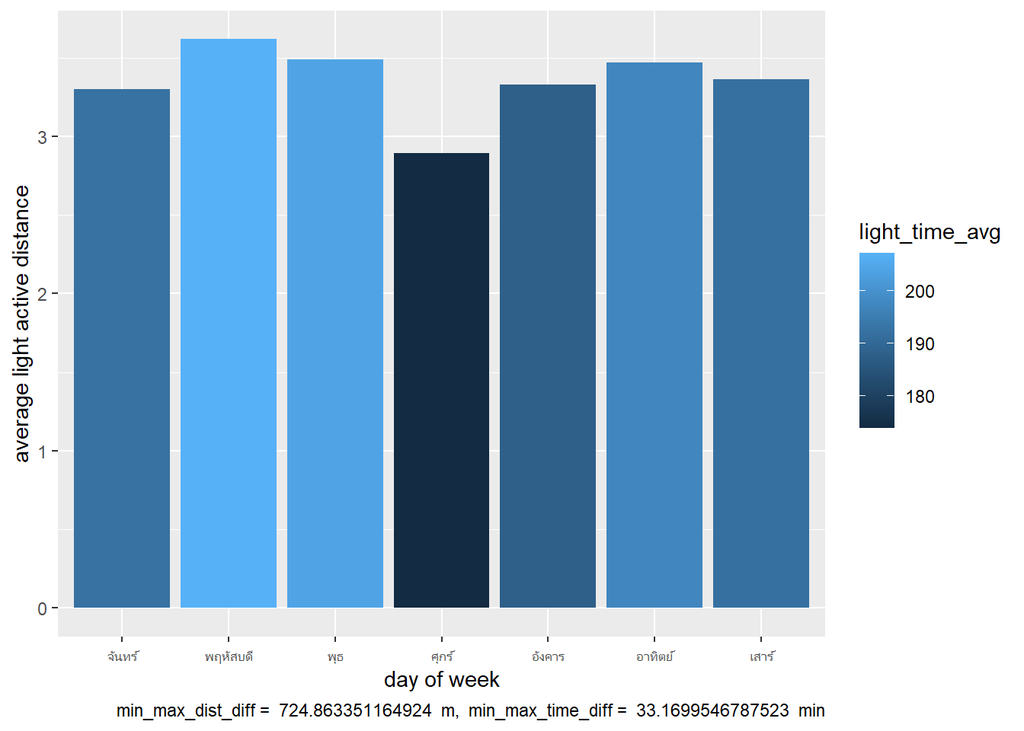

```r
light_dis_diff <- max(activity_day_summary$light_dis_avg) - min(activity_day_summary$light_dis_avg)
light_time_diff <- max(activity_day_summary$light_time_avg) - min(activity_day_summary$light_time_avg)
ggplot(data = activity_day_summary) +
  geom_col(mapping = aes(x = fct_inorder(day), y = light_dis_avg, fill = light_time_avg)) +
  labs(caption = paste("min_max_dist_diff = ",light_dis_diff*1000," m, ","min_max_time_diff = ",
                       light_time_diff, " min"), x = "day of week", y = "average light active distance",
       color = "average active time")
```

From knowing co-relation between light active time and calories, consider co-relation between light active time and sleep time

Preparing sleep data group by date

```r
sleep_date_summary <- sleep %>% group_by(date) %>%
  summarise(min_asleep_avg = mean(min_asleep), min_asleep_sd = sd(min_asleep), min_bed_avg = mean(min_bed),
            min_bed_sd = sd(min_bed), sleep_diff_avg = mean(min_bed - min_asleep))
head(sleep_date_summary)
```

```
## # A tibble: 6 × 6
##   date      min_asleep_avg min_asleep_sd min_bed_avg min_bed_sd sleep_diff_avg
##   <chr>              <dbl>         <dbl>       <dbl>      <dbl>          <dbl>
## 1 4/12/2016           442.         118.         480.      109.            37.8
## 2 4/13/2016           430.          98.8        472.       96.1           41.4
## 3 4/14/2016           445.          71.7        480.       53.9           35
## 4 4/15/2016           427.          89.0        476.      149.            48.9
## 5 4/16/2016           392.         168.         433       181.            41.3
## 6 4/17/2016           464.         162.         509.      164.            45.1
```

Merge data between activity and sleep data

```r
activity_sleep <- merge(activity_date_summary, sleep_date_summary, by = "date") %>%
  select(date, step_avg, dis_avg, light_dis_avg, light_time_avg, calories_avg, min_asleep_avg, min_asleep_sd, min_bed_avg,
         min_bed_sd, sleep_diff_avg)
head(activity_sleep)
```

```
##        date step_avg  dis_avg light_dis_avg light_time_avg calories_avg
## 1 4/12/2016 8236.848 5.982727      3.410000       199.0000     2390.697
## 2 4/13/2016 7198.727 5.103333      3.140909       181.7576     2286.636
## 3 4/14/2016 7743.576 5.599394      3.568485       201.0000     2356.394
## 4 4/15/2016 7533.848 5.287879      3.767273       213.8485     2355.182
## 5 4/16/2016 8679.156 6.291563      3.450625       193.8125     2392.938
## 6 4/17/2016 6409.250 4.540625      2.822188       165.3438     2230.969
##   min_asleep_avg min_asleep_sd min_bed_avg min_bed_sd sleep_diff_avg
## 1       441.9231     117.80454    479.6923  109.40246       37.76923
## 2       430.4286      98.84620    471.8571   96.13681       41.42857
## 3       445.2308      71.66142    480.2308   53.89829       35.00000
## 4       427.4706      88.99798    476.3529  149.20705       48.88235
## 5       391.7143     167.55271    433.0000  181.19518       41.28571
## 6       464.0833     161.69076    509.1667  163.97441       45.08333
```

### Scatter plot sleep time vs light active distance & time

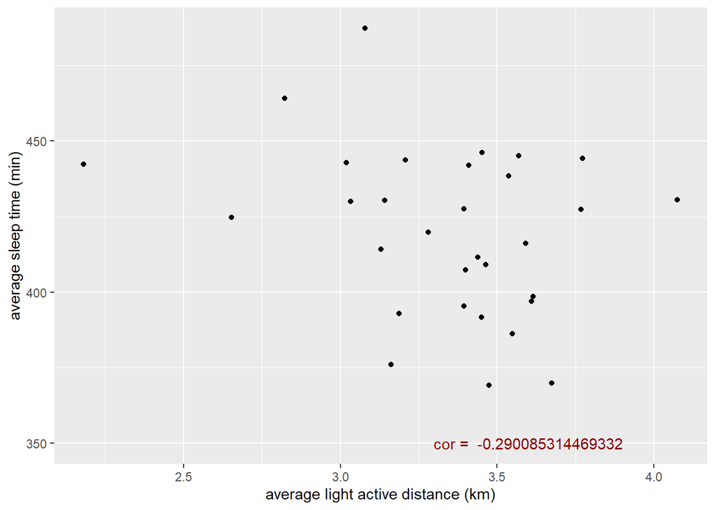

```r
cor_sleep_light <- cor(activity_sleep$min_asleep_avg, activity_sleep$light_dis_avg)
ggplot(data = activity_sleep) +
  geom_point(mapping = aes(x = light_dis_avg, y = min_asleep_avg)) +
  annotate("text", x = 3.6, y = 350, label = paste("cor = ",cor_sleep_light), color = "darkred") +
  labs(x = "average light active distance (km)", y = "average sleep time (min)")
```

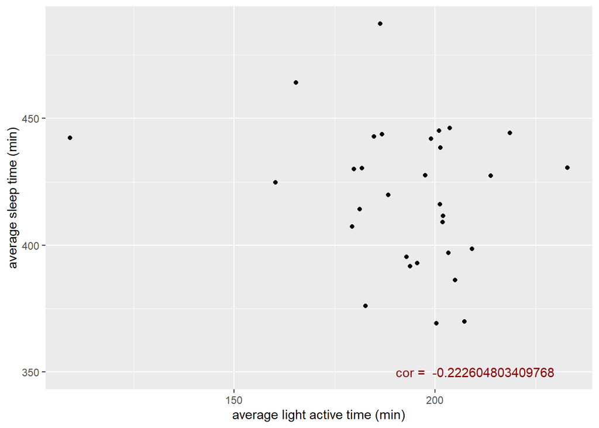

```r
cor_sleep_light_t <- cor(activity_sleep$min_asleep_avg, activity_sleep$light_time_avg)
ggplot(data = activity_sleep) +
  geom_point(mapping = aes(x = light_time_avg, y = min_asleep_avg)) +
  annotate("text", x = 210, y = 350, label = paste("cor = ",cor_sleep_light_t), color = "darkred") +
  labs(x = "average light active time (min)", y = "average sleep time (min)")
```

### Scatter plot sleep time vs step

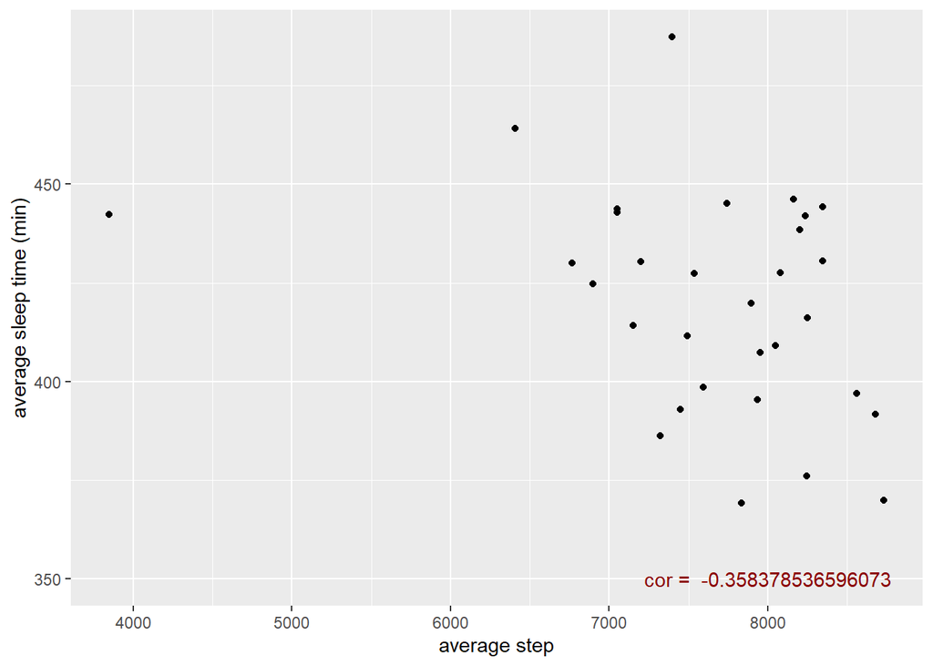

```r
cor_step_sleep <- cor(activity_sleep$step_avg, activity_sleep$min_asleep_avg)
ggplot(data = activity_sleep) +
  geom_point(mapping = aes(x = step_avg, y = min_asleep_avg)) +
  annotate("text", x = 8000, y = 350, label = paste("cor = ",cor_step_sleep), color = "darkred") +
  labs(x = "average step", y = "average sleep time (min)")
```

### Scatter plot sleep time vs distance

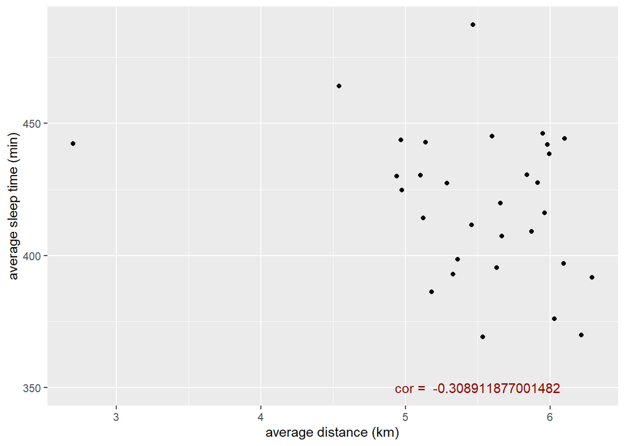

```r
cor_dis_sleep <- cor(activity_sleep$dis_avg, activity_sleep$min_asleep_avg)
ggplot(data = activity_sleep) +
  geom_point(mapping = aes(x = dis_avg, y = min_asleep_avg)) +
  annotate("text", x = 5.5, y = 350, label = paste("cor = ",cor_dis_sleep), color = "darkred") +
  labs(x = "average distance (km)", y = "average sleep time (min)")
```

### Scatter plot sleep time diff vs step

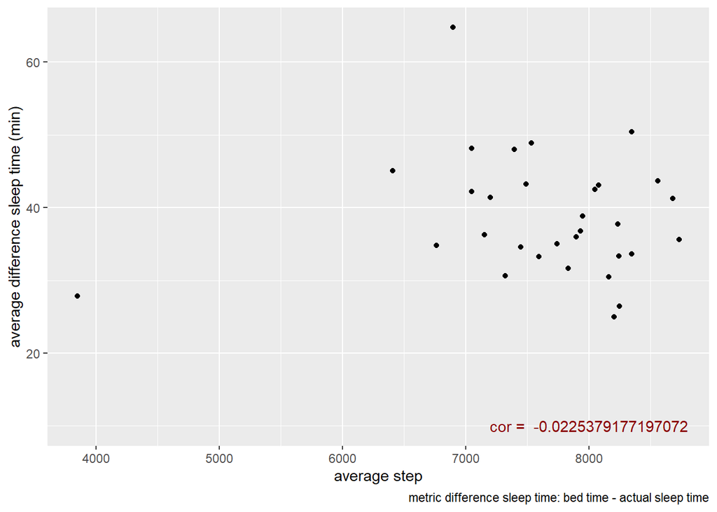

```r
cor_step_sleep_diff <- cor(activity_sleep$step_avg, activity_sleep$sleep_diff_avg)
ggplot(data = activity_sleep) +
  geom_point(mapping = aes(x = step_avg, y = sleep_diff_avg)) +
  annotate("text", x = 8000, y = 10, label = paste("cor = ",cor_step_sleep_diff), color = "darkred") +
  labs(x = "average step", y = "average difference sleep time (min)",
       caption = "metric difference sleep time: bed time - actual sleep time")
```

### Scatter plot sleep time diff vs distance

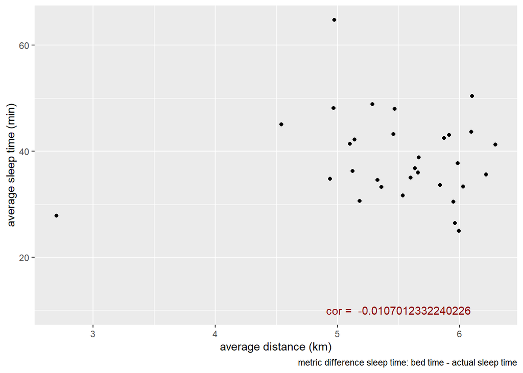

```r
cor_dis_sleep_diff <- cor(activity_sleep$dis_avg, activity_sleep$sleep_diff_avg)
ggplot(data = activity_sleep) +
  geom_point(mapping = aes(x = dis_avg, y = sleep_diff_avg)) +
  annotate("text", x = 5.5, y = 10, label = paste("cor = ",cor_dis_sleep_diff), color = "darkred") +
  labs(x = "average distance (km)", y = "average sleep time (min)",
       caption = "metric difference sleep time: bed time - actual sleep time")
```

### Scatter plot sleep time vs calories

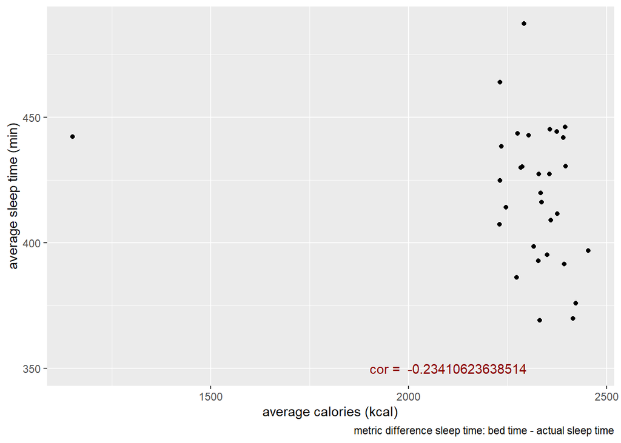

```r
cor_cal_sleep <- cor(activity_sleep$calories_avg, activity_sleep$min_asleep_avg)
ggplot(data = activity_sleep) +
  geom_point(mapping = aes(x = calories_avg, y = min_asleep_avg)) +
  annotate("text", x = 2100, y = 350, label = paste("cor = ",cor_cal_sleep), color = "darkred") +
  labs(x = "average calories (kcal)", y = "average sleep time (min)",
       caption = "metric difference sleep time: bed time - actual sleep time")
```

There seem like no trend between activity data and sleep time

## Summarise

- Users are more likely to walk than run or jogging.
- Calories burning has a correlation with step of users.
- The more time users spend on light activity, the more calories burned.
- Users are doing more light activity between Wednesday and Thursday.
- There is no correlation between activity and sleep time data.

## High-level Recommendation

- Promote the Time to users who love to do light activities. And provide information that doing more light activity causes more calories to burn.